# Data Science Capstone Project Yelp - Exploring Business open/closed status

TJ  
21 November 2015

### Introduction

This report is created in scope of the Data Science Capstone Session Yelp, which is the final part of the Data Science Specialization in [Coursera](https://www.coursera.org/specializations/jhudatascience?utm_medium=courseDescripTop) and try to find the answer if the review text can predict the business open status.

The sentiment analysis of the review text may help to find correlation with the business open status and support owners with early warning prior to close their business.

The data for this capstone come from [Yelp](http://www.yelp.com/), which is a business founded in 2004 to “help people find great local businesses like dentists, hair stylists and mechanics.”

### Methods and Data

Steps completed during the analysis:

- Load and clean the review, business and user data sets, then narrow them to US located cities.
- Create functions to explore the review text and count positive (P) and negative (N) sentiment words ([Opinion Lexicon: Positive and Negative](http://www.cs.uic.edu/%7Eliub/FBS/sentiment-analysis.html)).
- Merge the datasets and calculate sentiment value *(SV = P - N)* and sentiment rate *(SR = P / N, if P = 0, then SR = 0, if N = 0, then SR = 50)*.
- Separate the data set into training and testing data sets and test the null hypothesis
- First method: use correlation matrix to show how the values are correlated to each other.
- Second method: calculate P-value with Fisher test to see if the variables are independent from each other.

### Results

The correlation matrix shows no significant correlation between the open status and other variables & the P-values of the Fisher test are the following:

- P-value of open vs. sentiment value or rate: 0.2805894 or 0.2455738
- Fisher test P-value for stars vs. sentiment rate: 4.998 × 10<sup>-4</sup>

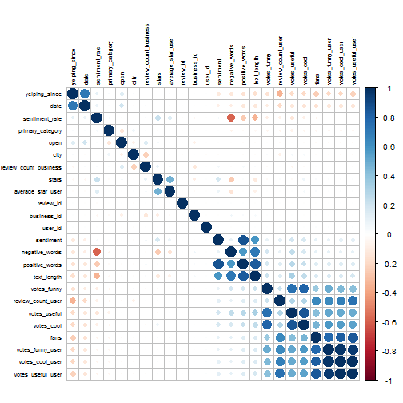

### Discussion

Correlation Matrix shows almost no correlation between open and sentiment value or rate and Fisher test resulted higher P-values, which suggest that the null hypothesis is true, and the open value is independent from the review text sentiment value or rate. The Fisher test also used to test the independence of review star with sentiment rate, in that case the much lower P-value suggest relation between the tested cases.

This implicates, that the data set has not enough information to use for open status prediction, supporting business owners with early warning prior to close the business.

The Data Science Capstone Project Report source **[Rmd file](https://github.com/Datarch/Capstone)** avaible on GitHub.